# Introduction_to_ReliableTrendIndex

```r
library(ReliableTrendIndex)
```

The package `{ReliableTrendIndex}` is a way to contain a large group of disorganized analysis functions related to the concept of reliable change. There are a few key functions.

### `reliableTrend()` and the `reliableTrend` class

The function `reliableTrend()` creates objects of class `reliableTrend`. This class is just a list with fixed, named entries. You can read about it in `?reliableTrend()`.

### Meta-analysis backbone

The most central RTI functions are wrappers around functions from the `{metafor}` package, available on CRAN. The chief of these is `metafor::rma()`, which conducts simple univariate meta-analyses. Read about it at `?metafor::rma()`. It was worth developing wrapper functions because **A)** those functions are much more complex than the RCI/RTI require, and **B)** the variables in that package are named appropriately for meta-analysis, but not for this purpose.

At present, any upstream changes to `{metafor}` will affect this package. This should not be a major problem, but may become an issue in the future. I have decided not to extract the functions directly from `{metafor}` at present.

## Conceptual differences between RTI and RCI

The RCI is a test for difference scores, and the RTI is a test for linear trends. The two are fundamentally different, but both can be informative about change. If there is a reliable change according to the RCI, the individual has provided scores that are not consistent with having the same true score at both occasions. If there is a reliable trend according to the RTI, the individual’s series of scores is not consistent with a constant mean true score value. These are potentially different pieces of information.

Patients who have a reliable trend have experienced change. Patients who have a reliable change have a reliable difference between two points. Patients who have a reliable trend but no reliable change have experienced change but would not be reliably different if only two observations were available. Patients who have a reliable change but no reliable trend are reliably different, but may not be changing.

The differences are, admittedly, difficult to understand and circumstantially variable. Preference for one or the other can be justified. Both methods will create unnecessary Type II errors by failing to categorize some individuals with small-to-moderate changes. The RTI will resolve some of the Type II errors that the RCI creates.

Since both the RTI and the RCI assume the same error component, but the RTI includes more observations, it will have a higher signal-to-noise ratio than the RCI. However, nonlinear changes will reduce this effect.

I recommend using the RTI if you want a simple way to use multiple observations per person, and think that each observation includes information about their overall process of change. The RCI requires that you believe only two observations matter.

The solution that resolves these issues is to collect better data: more precise measurements with greater person-specificity and more frequent assessments during a change process.

## Workflow with multiple people

Some basic usage examples are provided in `?reliableTrend`, `?simple_rma`, `?rti_to_df` and others.

The two essential use cases are when you have one person, and when you have more than one person.

See the README for examples with a single person. That workflow is only relevant to specific clinical testing situations, and as educational material.

In the case of analyzing a lot of data simultaneously (*e.g.*, in a research project, clinical administration/program evaluation, simulation study), the simplest way to think about it is doing the a single case iteratively.

However, you might have one, two, or several hundred observations for a given person, that number of observations might differ across people, and there might be many hundreds of individuals in your data. It would be ideal to have an analysis system that could handle all of those cases without so much work.

We have a simulated data set available in the package.

```r
simulated_data
```

```
#> # A tibble: 5,995 × 10
#>       id num_obs BL_true Final_t…¹ diff_…² index incre…³ true_…⁴ true_…⁵ obs_s…⁶
#>    <int>   <int>   <dbl>     <dbl>   <dbl> <dbl>   <dbl>   <dbl> <chr>     <dbl>
#>  1     1      12   0.199     0.513   0.314     0  0.0285   0.199 True I…  0.0847
#>  2     1      12   0.199     0.513   0.314     1  0.0285   0.228 True I…  0.123
#>  3     1      12   0.199     0.513   0.314     2  0.0285   0.256 True I…  0.451
#>  4     1      12   0.199     0.513   0.314     3  0.0285   0.285 True I…  0.0745
#>  5     1      12   0.199     0.513   0.314     4  0.0285   0.313 True I…  0.0854
#>  6     1      12   0.199     0.513   0.314     5  0.0285   0.342 True I…  0.477
#>  7     1      12   0.199     0.513   0.314     6  0.0285   0.370 True I…  0.353
#>  8     1      12   0.199     0.513   0.314     7  0.0285   0.399 True I…  0.495
#>  9     1      12   0.199     0.513   0.314     8  0.0285   0.427 True I…  0.299
#> 10     1      12   0.199     0.513   0.314     9  0.0285   0.456 True I…  0.794
#> # … with 5,985 more rows, and abbreviated variable names ¹Final_true,
#> #   ²diff_true, ³increment, ⁴true_score, ⁵true_change, ⁶obs_score
```

The data has 500 individuals (`id`) with true scores at varying number of observations. Each person was measured between 4-20 times. (If you have fewer than 4 observations per person, the RTI will return the same value as the RCI as of version 0.1.)

This data was simulated with an average effect of increasing scores over time, and the true scores all follow a linear pattern, but there is noise added to the `obs_score` variable. Specifically, it has a random normal variable added with SD = .2.

We can use this information to compute the RCI and RTI categories across all the data. The code chunk below does this, and some additional work. It is commented to explain each step.

```r
sim_data_2 <- simulated_data %>%
  # split the data by the id variable
  split(.$id) %>%
  # compute the rti for each separate data set
  purrr::map(~ rti(values = .$obs_score, sem = .2)) %>%
  # take the output and simplify it to data.frame-friendly columns
  purrr::map_dfr(rti_to_df) %>%
  # the data is made in a very simple form
  # HOWEVER, it lost several key variables along the way
  # here, we re-merge the old data (simulated_data) with the new
  # first by re-integrating the id variable, which was dropped earlier
  mutate(id = simulated_data %>%
           group_by(id) %>%
           slice_tail(n = 1) %>%
           pull(id)) %>%
  # then joining the data sets
  right_join(simulated_data) %>%
  # now computing first and last score values, which are not natively in the data
  group_by(id) %>%
  mutate(first_obs = first(obs_score),
         last_obs = last(obs_score)) %>%
  # and finally taking just the last observation per person.
  slice_tail(n = 1)
```

That code is not the easiest to understand, but it does work and would work for a range of data sets.

Since we only retained one row per patient, comparing the RCI and RTI is relatively straightforward:

```r
table(sim_data_2$category.RCI)
```

```
#>
#> Less than reliable  Reliable Decrease  Reliable Increase
#>                145                131                224
```

```r
table(sim_data_2$category.RTI)
```

```
#>
#> Less than reliable  Reliable Decrease  Reliable Increase
#>                 90                152                258
```

But how does that compare to the “reality?” Meaning, the true score increase/decreases.

```r
table(sim_data_2$category.RCI,
      sim_data_2$category.RTI,
      sim_data_2$true_change)
```

```
#> , ,  = True Decrease
#>
#>
#>                      Less than reliable Reliable Decrease Reliable Increase
#>   Less than reliable                 41                24                 0
#>   Reliable Decrease                   2               128                 0
#>   Reliable Increase                   0                 0                 0
#>
#> , ,  = True Increase
#>
#>
#>                      Less than reliable Reliable Decrease Reliable Increase
#>   Less than reliable                 46                 0                34
#>   Reliable Decrease                   1                 0                 0
#>   Reliable Increase                   0                 0               224
```

The top table is people whose true scores truly decreased, the bottom are the people whose true scores truly increased. The rows are the RCI categories and the columns are the RTI.

We can see that:

- 24 people who truly decreased were identified correctly by the RTI but ‘Less than reliable’ by the RCI. In contrast, the RCI only identified 2 people who truly decreased while the RTI said they were ‘Less than reliable.’

Overall, other comparisons are in favor of the RTI in most cases.

RCI versus truth:

```r
table(sim_data_2$category.RCI, sim_data_2$true_change)
```

```
#>
#>                      True Decrease True Increase
#>   Less than reliable            65            80
#>   Reliable Decrease            130             1
#>   Reliable Increase              0           224
```

RTI versus truth:

```r
table(sim_data_2$category.RTI, sim_data_2$true_change)
```

```
#>
#>                      True Decrease True Increase
#>   Less than reliable            43            47
#>   Reliable Decrease            152             0
#>   Reliable Increase              0           258
```

This simulation is fairly favorable to the RCI, as it allows the RCI to classify about 70% of individuals. In applied data, this would be unusual (though not unheard of), because the RCI often fails to classify 40-70% of individuals in mental health treatments (as a function of the ratio of reliability to effect size).

### Plotting the sample

It is possible to construct a plot with pre-post scores indicating individuals’ RCI status.

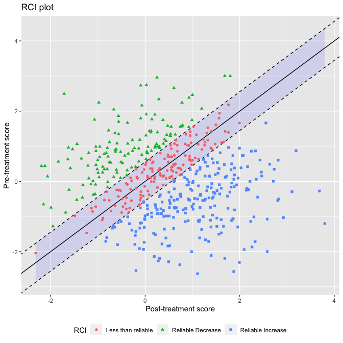

```r
ggplot(data = sim_data_2,
       aes(x = last_obs,
           y = first_obs)) +
  geom_abline(slope = 1,
              intercept = c(0,
                            1.96*.2*sqrt(2),
                            -1.96*.2*sqrt(2)),
              linetype = c("solid", "dashed", "dashed")) +
  geom_ribbon(aes(ymax = last_obs + 1.96*.2*sqrt(2),
                  ymin = last_obs - 1.96*.2*sqrt(2)),
              fill = "blue",
              alpha = .1) +
  geom_point(aes(shape = category.RCI,
                 color = category.RCI)) +
  scale_shape_discrete(name = "RCI") +
  scale_color_discrete(name = "RCI") +
  labs(title = "RCI plot",
       y = "Pre-treatment score",
       x = "Post-treatment score") +
  theme(legend.position = "bottom")
```

That plot is similar to the Jacobson & Truax method, and shows the traditional effects. We could construct an analogous plot with the RTI categories:

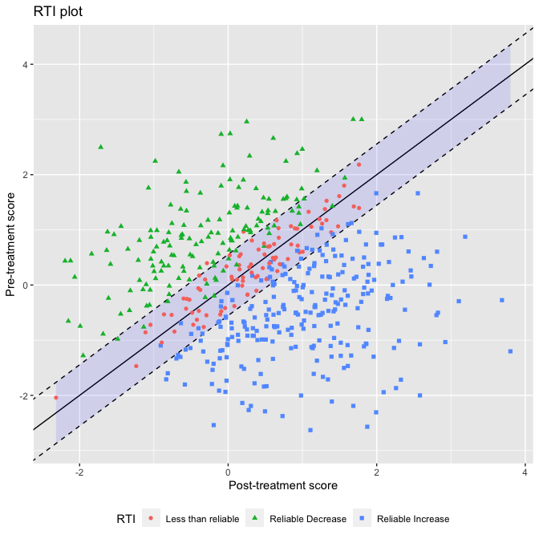

```r
ggplot(data = sim_data_2,
       aes(x = last_obs,
           y = first_obs)) +
  geom_abline(slope = 1,
              intercept = c(0,
                            1.96*.2*sqrt(2),
                            -1.96*.2*sqrt(2)),
              linetype = c("solid", "dashed", "dashed")) +
  geom_ribbon(aes(ymax = last_obs + 1.96*.2*sqrt(2),
                  ymin = last_obs - 1.96*.2*sqrt(2)),
              fill = "blue",
              alpha = .1) +
  geom_point(aes(shape = category.RTI,
                 color = category.RTI)) +
  scale_shape_discrete(name = "RTI") +
  scale_color_discrete(name = "RTI") +
  labs(title = "RTI plot",
       y = "Pre-treatment score",
       x = "Post-treatment score") +
  theme(legend.position = "bottom")
```

In that plot, we can see many of the points within the RCI’s uncertainty band are actually reliably changing during the observation period, and a small number of points outside it are actually not reliably changing.

A more RTI-centric plot would involve estimating the linear trend along with its uncertainty, much like a caterpillar plot, or a plot of the estimated confidence in Increase/Decrease directly.

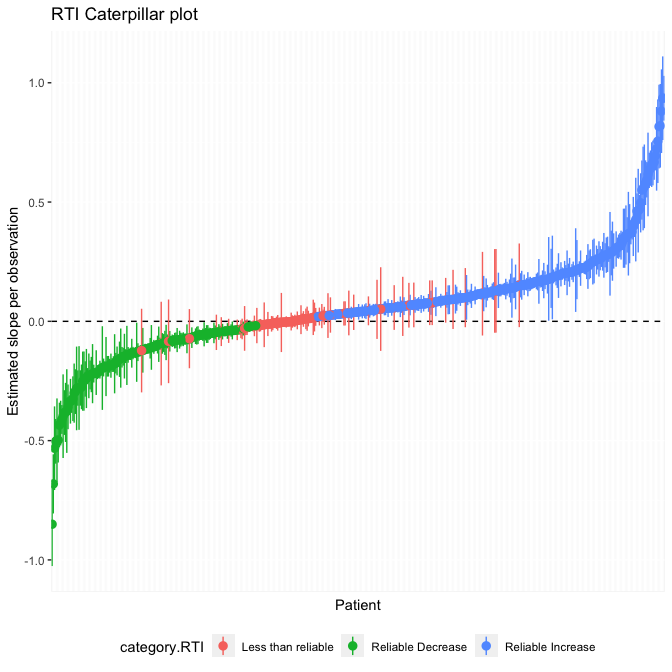

```r
ggplot(sim_data_2,
       aes(x = reorder(slope.est, slope.est),
           y = slope.est,
           ymin = slope.lb,
           ymax = slope.ub)) +
  geom_hline(yintercept = 0,
             linetype = "dashed") +
  geom_pointrange(aes(color = category.RTI)) +
  labs(title = "RTI Caterpillar plot",
       x = "Patient",
       y = "Estimated slope per observation") +
  theme(axis.text.x = element_blank(),
        axis.ticks.x = element_blank(),
        legend.position = "bottom")
```

Compare that plot to the same observations colored by the corresponding RCI categories:

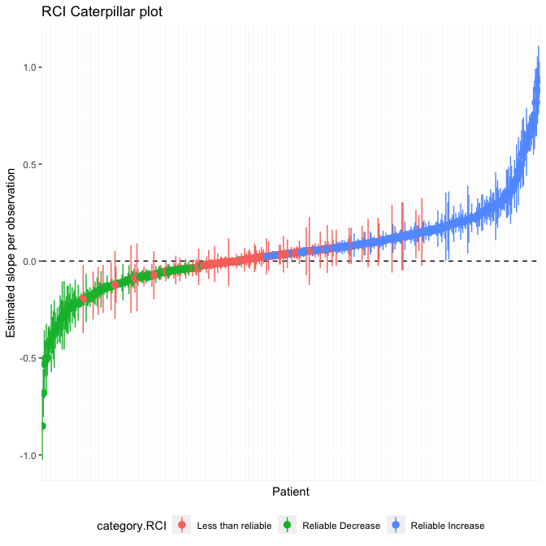

```r
ggplot(sim_data_2,
       aes(x = reorder(slope.est, slope.est),
           y = slope.est,
           ymin = slope.lb,
           ymax = slope.ub)) +
  geom_hline(yintercept = 0,
             linetype = "dashed") +
  geom_pointrange(aes(color = category.RCI)) +
  labs(title = "RCI Caterpillar plot",
       x = "Patient",
       y = "Estimated slope per observation") +
  theme(axis.text.x = element_blank(),
        axis.ticks.x = element_blank(),
        legend.position = "bottom")
```

Here we are showing the same RTI data and error bars, only coloring it by the RCI. The differences are relatively minor in this case, and occur only in two cases: The first and more common case is when the RTI’s CI excludes 0 but the RCI is not able to notice this (it always as as large or larger error).

The second cause is when the pre-post difference score is larger than the RTI’s estimated slope over that time interval, and the increase in precision due to using the RTI does not compensate for the smaller estimate of change. This occurs seldom, and will be due to an unusually large pre-post difference score compared to the other observations for an individual - in this data, due entirely to measurement error. That is, the RCI detected a large change mostly due to measurement error, while the RTI detected a smaller or less consistent change based on more observations.

A confidence in change plot.

WIP::

```r
sim_data_3 <- sim_data_2 %>%
  ungroup() %>%
  mutate(diff_obs = last_obs - first_obs) %>%
  arrange(diff_obs)

max(sim_data_3$diff_obs)
```

```
#> [1] 5.00108
```

```r
class(sim_data_3$diff_obs)
```

```
#> [1] "numeric"
```

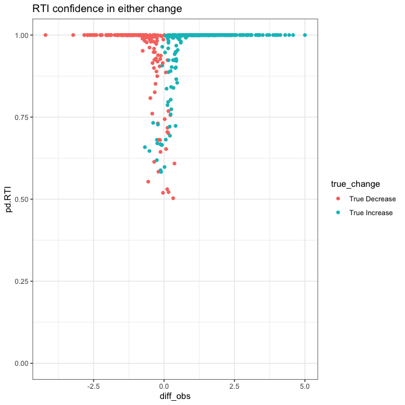

```r
ggplot(sim_data_3,
       aes(x = diff_obs,
           y = pd.RTI)) +
  geom_point(aes(color = true_change)) +
  lims(y = c(0, 1)) +
  theme_bw() +
  labs(title = "RTI confidence in either change")
```

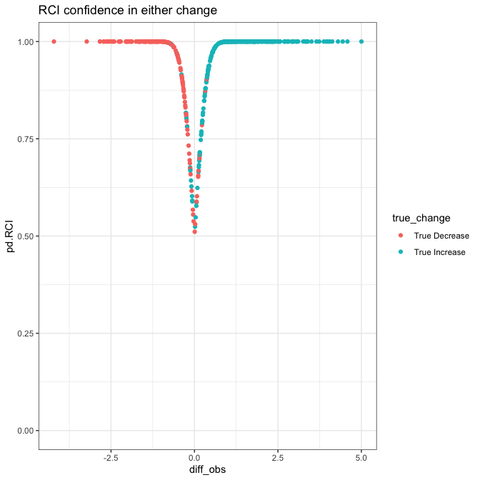

```r
ggplot(sim_data_3,
       aes(x = diff_obs,
           y = pd.RCI)) +
  geom_point(aes(color = true_change)) +
  lims(y = c(0, 1)) +
  theme_bw() +
  labs(title = "RCI confidence in either change")
```

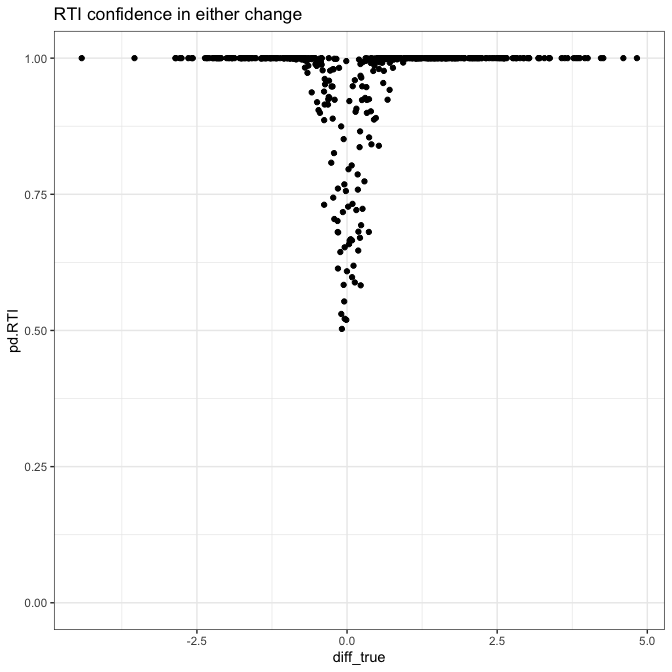

```r
ggplot(sim_data_3 %>%
         arrange(diff_true),
       aes(x = diff_true,
           y = pd.RTI)) +
  geom_point() +
  lims(y = c(0, 1)) +
  theme_bw() +
  labs(title = "RTI confidence in either change")
```

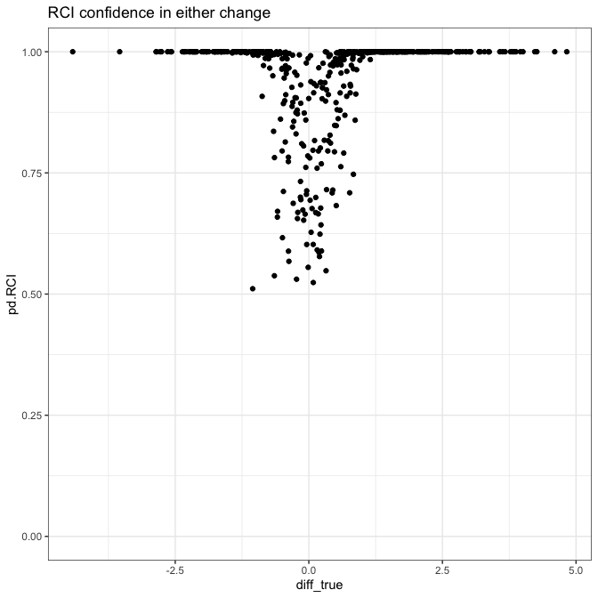

```r
ggplot(sim_data_3 %>%
         arrange(diff_true),
       aes(x = diff_true,
           y = pd.RCI)) +
  geom_point() +
  lims(y = c(0, 1)) +
  theme_bw() +
  labs(title = "RCI confidence in either change")
```

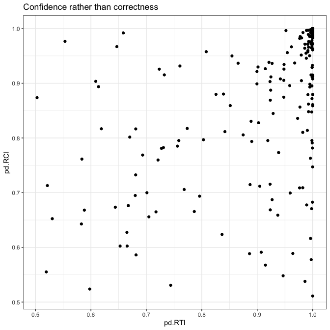

```r
ggplot(sim_data_3 %>%
         arrange(diff_true),
       aes(x = pd.RTI,
           y = pd.RCI)) +
  geom_point() +
  # lims(y = c(0, 1),
  #      x = c(0, 1)) +
  theme_bw() +
  labs(title = "Confidence rather than correctness")
```